# Association Rules - Market Basket Analysis using Apriori

Weronika Mądro

## Introduction

Basket analysis is often used to discover relationships between items in transactional data. It is commonly applied in retail to identify purchasing patterns and generate actionable insights, such as cross-selling strategies or product placement optimization. By analyzing transaction data, basket analysis seeks to uncover associations or correlations between products that are frequently bought together.

For this project, I am using a dataset sourced from Kaggle: “https://www.kaggle.com/datasets/rukenmissonnier/real-market-data”. This dataset provides real-world transactional data, ideal for exploring association rules.

## Association rules

Association rules are a fundamental concept in data mining and machine learning, designed to identify interesting relationships between variables in large datasets. The process involves three main metrics to evaluate the strength and usefulness of these rules: support, confidence and lift. By uncovering hidden patterns and relationships in data, association rules provide valuable insights that drive strategic decision-making.

## Preprocessing

First step in the project is to load the data, check its structure and summarize.

```r
market <- read.csv("market.csv", sep = ";")
summary(market)
```

```
##      Bread            Honey            Bacon         Toothpaste
##  Min.   :0.0000   Min.   :0.0000   Min.   :0.000   Min.   :0.0000
##  1st Qu.:0.0000   1st Qu.:0.0000   1st Qu.:0.000   1st Qu.:0.0000
##  Median :0.0000   Median :0.0000   Median :0.000   Median :0.0000
##  Mean   :0.4073   Mean   :0.4159   Mean   :0.431   Mean   :0.3836
##  3rd Qu.:1.0000   3rd Qu.:1.0000   3rd Qu.:1.000   3rd Qu.:1.0000
##  Max.   :1.0000   Max.   :1.0000   Max.   :1.000   Max.   :1.0000
##      Banana           Apple           Hazelnut          Cheese
##  Min.   :0.0000   Min.   :0.0000   Min.   :0.0000   Min.   :0.000
##  1st Qu.:0.0000   1st Qu.:0.0000   1st Qu.:0.0000   1st Qu.:0.000
##  Median :0.0000   Median :0.0000   Median :0.0000   Median :0.000
##  Mean   :0.4483   Mean   :0.4052   Mean   :0.4203   Mean   :0.444
##  3rd Qu.:1.0000   3rd Qu.:1.0000   3rd Qu.:1.0000   3rd Qu.:1.000
##  Max.   :1.0000   Max.   :1.0000   Max.   :1.0000   Max.   :1.000
##       Meat            Carrot          Cucumber          Onion
##  Min.   :0.0000   Min.   :0.0000   Min.   :0.0000   Min.   :0.0000
##  1st Qu.:0.0000   1st Qu.:0.0000   1st Qu.:0.0000   1st Qu.:0.0000
##  Median :0.0000   Median :0.0000   Median :0.0000   Median :0.0000
##  Mean   :0.3879   Mean   :0.4138   Mean   :0.3815   Mean   :0.3793
##  3rd Qu.:1.0000   3rd Qu.:1.0000   3rd Qu.:1.0000   3rd Qu.:1.0000
##  Max.   :1.0000   Max.   :1.0000   Max.   :1.0000   Max.   :1.0000
##       Milk            Butter       ShavingFoam          Salt
##  Min.   :0.0000   Min.   :0.000   Min.   :0.0000   Min.   :0.0000
##  1st Qu.:0.0000   1st Qu.:0.000   1st Qu.:0.0000   1st Qu.:0.0000
##  Median :0.0000   Median :0.000   Median :0.0000   Median :0.0000
##  Mean   :0.3707   Mean   :0.375   Mean   :0.4052   Mean   :0.3987
##  3rd Qu.:1.0000   3rd Qu.:1.000   3rd Qu.:1.0000   3rd Qu.:1.0000
##  Max.   :1.0000   Max.   :1.000   Max.   :1.0000   Max.   :1.0000
##      Flour          HeavyCream          Egg            Olive
##  Min.   :0.0000   Min.   :0.0000   Min.   :0.000   Min.   :0.0000
##  1st Qu.:0.0000   1st Qu.:0.0000   1st Qu.:0.000   1st Qu.:0.0000
##  Median :0.0000   Median :0.0000   Median :0.000   Median :0.0000
##  Mean   :0.3858   Mean   :0.4159   Mean   :0.403   Mean   :0.3815
##  3rd Qu.:1.0000   3rd Qu.:1.0000   3rd Qu.:1.000   3rd Qu.:1.0000
##  Max.   :1.0000   Max.   :1.0000   Max.   :1.000   Max.   :1.0000
##     Shampoo           Sugar
##  Min.   :0.0000   Min.   :0.0000
##  1st Qu.:0.0000   1st Qu.:0.0000
##  Median :0.0000   Median :0.0000
##  Mean   :0.3664   Mean   :0.3664
##  3rd Qu.:1.0000   3rd Qu.:1.0000
##  Max.   :1.0000   Max.   :1.0000
```

```r
str(market)
```

```
## 'data.frame':    464 obs. of  22 variables:
##  $ Bread      : int  1 1 0 1 0 0 0 0 0 0 ...
##  $ Honey      : int  0 1 1 1 1 1 0 0 1 0 ...
##  $ Bacon      : int  1 1 1 0 0 0 1 1 1 0 ...
##  $ Toothpaste : int  0 0 1 1 0 1 0 1 0 0 ...
##  $ Banana     : int  1 1 1 0 0 0 1 1 1 0 ...
##  $ Apple      : int  1 1 1 1 0 0 1 0 1 0 ...
##  $ Hazelnut   : int  1 1 1 0 0 1 0 1 1 0 ...
##  $ Cheese     : int  0 0 1 0 0 0 0 0 1 0 ...
##  $ Meat       : int  0 0 1 0 0 0 0 0 1 0 ...
##  $ Carrot     : int  1 0 0 0 0 0 1 0 1 0 ...
##  $ Cucumber   : int  0 1 1 1 0 0 0 1 0 0 ...
##  $ Onion      : int  0 0 1 1 0 1 0 1 1 1 ...
##  $ Milk       : int  0 1 1 1 0 0 0 0 0 1 ...
##  $ Butter     : int  0 1 0 0 0 0 0 0 1 0 ...
##  $ ShavingFoam: int  0 0 1 0 0 1 0 0 1 0 ...
##  $ Salt       : int  0 0 1 0 0 0 1 1 0 1 ...
##  $ Flour      : int  0 1 1 1 0 0 0 0 0 1 ...
##  $ HeavyCream : int  1 0 1 0 0 0 1 0 1 1 ...
##  $ Egg        : int  1 0 1 1 0 0 0 1 1 0 ...
##  $ Olive      : int  0 1 0 1 0 0 0 0 1 0 ...
##  $ Shampoo    : int  0 1 0 1 0 0 0 0 0 1 ...
##  $ Sugar      : int  1 0 1 0 0 1 0 0 0 0 ...
```

The statistics indicate that all products fall within the range of 0 and 1, which aligns with the dataset’s binary structure based on 0-1 logic. The structure of the data proves it.

To simplify working with the data, I decided to reorganize it so that, instead of 0s and 1s in the columns, the product names themselves are displayed.

```r
columns <- c("Bread", "Honey", "Bacon", "Toothpaste", "Banana", "Apple", "Hazelnut",
             "Cheese", "Meat", "Carrot", "Cucumber", "Onion", "Milk", "Butter",
             "ShavingFoam", "Salt", "Flour", "HeavyCream", "Egg", "Olive", "Shampoo", "Sugar")

market_transformed <- as.data.frame(lapply(columns, function(col) {
  ifelse(market[[col]] == 1, col, "")
}))

colnames(market_transformed) <- columns
```

```r
basket_data <- apply(market_transformed, 1, function(row) {
  paste(row[row != ""], collapse = ",")
})
```

A new CSV file has been created and it’s going to be assigned to a new variable with a basket format.

```r
writeLines(basket_data, "market_basket.csv")
```

The next step will be to analyze and summarize the transactions, providing insights into the overall structure and key patterns in the data.

```r
library(arules)
transaction <- read.transactions("market_basket.csv", format = "basket", sep = ",")
summary(transaction)
```

```
## transactions as itemMatrix in sparse format with
##  464 rows (elements/itemsets/transactions) and
##  22 columns (items) and a density of 0.3993926
##
## most frequent items:
##     Banana     Cheese      Bacon   Hazelnut HeavyCream    (Other)
##        208        206        200        195        193       3075
##
## element (itemset/transaction) length distribution:
## sizes
##  1  2  3  4  5  6  7  8  9 10 11 12 13 14 15 16 17
## 19 22 11 30 33 28 25 35 37 45 42 43 41 27 18  5  3
##
##    Min. 1st Qu.  Median    Mean 3rd Qu.    Max.
##   1.000   6.000   9.000   8.787  12.000  17.000
##
## includes extended item information - examples:
##   labels
## 1  Apple
## 2  Bacon
## 3 Banana
```

The inspect function lists the transactions.

```r
inspect(transaction)
```

[output not shown]

[output cut: 4023 more lines]

[output not shown]

Size and length are being checked in this step.

```r
size(transaction)
```

```
##   [1]  9 12 17 11  1  6  6  8 14  6 10  9 15 13 10  4  3  4 13 14  4  9 10  8  7
##  [26] 12  5  9 12  9 13 14 12 14  9 12  7  2  9  8  4  4  5 12 10  9  1 12 12 11
##  [51] 12 11  6  9 14 10  7 15  3 13  9 10  6 12 15 13 12 10 12 14 13  8 11 11  6
##  [76]  4  1 14 13 13  8  7  2  5  6  9  5 11 14  3 10  4 14 10  9  4  6 13 15  8
## [101]  9 10 16  5  4  8 11  2 13  9 10 10  8  5 13  4  4  8 14  4  6 13 13  7  7
## [126] 11 12 11 12 10 14 12  7  9  5 16  8  9 12 12 15  6  6 12 12  1  5  2 13  1
## [151]  7  4  4  3 11  5  1  9 14  8 10  5  8  8 11 11 15  5 12 14  4 11  1  4  5
## [176] 11  7 13 13 10  5 15  5  5 13 14  1 11 10  8 12  2  5 12  8  6  9  7  8  5
## [201]  9 12 11  8  1  4  5 13  9  9 10  9 12 15 10  3  7 17 11  6  4 11 12 13 13
## [226]  3 12  8 10 10 11 10  6  8 11  2 12 14  6 12  1  2  4 12 13 13 15  7  6  5
## [251]  5  8  1  5  8 11  6  1 10 11  8  5  6 14 13  2  2  2 15  1 13 14 11 11  4
## [276]  4  2 12 13 14 14  8 13  3  5  9 14 12  7  9  1  4  7  7 10  6  5  8 15  4
## [301] 16 11 12 15  6  8 13  8  7  9  2 11 13 11 14  4 11 11 13  6 15  6  1 11 11
## [326]  7 13  9 13  5 10 12  1 13  6  4 10 10 10  6  7 10  5  5  7 12  2  5  8  7
## [351]  9 14 15  7 11  9  8  4  9  4  5 10  3  2 10  4 12 14  8  2 10 10 10 16 10
## [376] 10  7  2 15  5  9 13 12  7  2  9 12  6  4 10  5  9 13  4 13 13  5  8 10 17
## [401] 10 11  2 12  8  6 11 14 13  1 11 11  7 14  9  9  3 13  3  8 13 10 12 15 12
## [426] 11 10 14  8  8  2 10 11  1  9  2  2 11 13 13  8 12 10  6 10 16  7 11 12 10
## [451]  2 11  9  1  9 14 15 10  3 15  6  5 12 11
```

```r
length(transaction)
```

```
## [1] 464
```

There are 464 transactions.

A plot of transaction item frequencies has now been created to analyze which products were purchased most often. The values displayed on the plot represent relative frequencies, indicating the proportion of each product’s occurrences. Additionally, a table with absolute frequency values is provided below the plot for a more detailed view of the data.

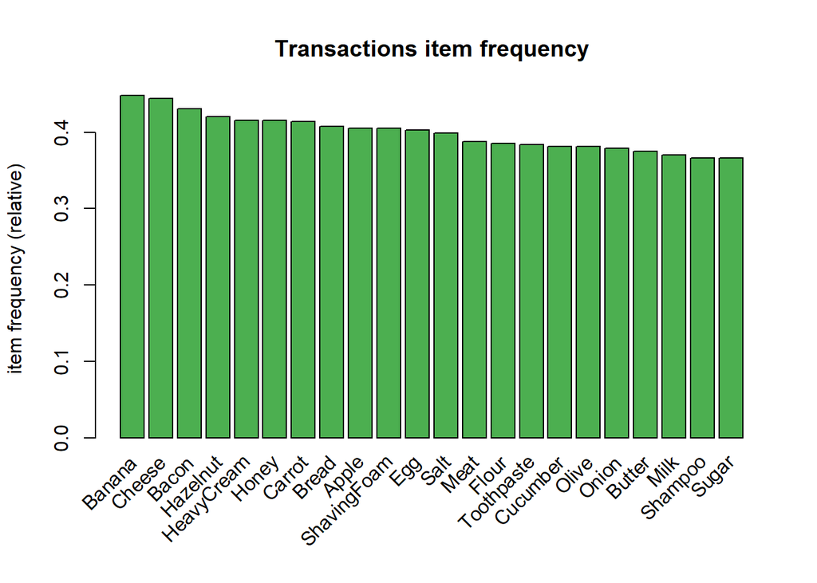

```r
itemFrequencyPlot(transaction, topN=22, type="relative", main="Transactions item frequency", col="#4CAF50")
```

```r
itemFrequency(transaction, type="absolute")
```

```
##       Apple       Bacon      Banana       Bread      Butter      Carrot
##         188         200         208         189         174         192
##      Cheese    Cucumber         Egg       Flour    Hazelnut  HeavyCream
##         206         177         187         179         195         193
##       Honey        Meat        Milk       Olive       Onion        Salt
##         193         180         172         177         176         185
##     Shampoo ShavingFoam       Sugar  Toothpaste
##         170         188         170         178
```

## Apriori Algorithm

Apriori Algorithm is a foundational method in data mining used for discovering frequent itemsets and generating association rules. The algorithm starts by analyzing the dataset to find how often individual items appear and sets a minimum support value to decide which items are frequent. It then combines these frequent items to create pairs (2-item groups) and continues this process to form larger groups until no more frequent groups are found. To save time, it removes any itemsets that are not frequent, as their larger combinations will also be infrequent. Finally, the algorithm creates association rules to show how items are connected, using support, confidence and lift to measure the strength of these relationships.

```r
rules<-apriori(transaction, parameter=list(supp=0.1, conf=0.65, minlen=2))
```

```
## Apriori
##
## Parameter specification:
##  confidence minval smax arem  aval originalSupport maxtime support minlen
##        0.65    0.1    1 none FALSE            TRUE       5     0.1      2
##  maxlen target  ext
##      10  rules TRUE
##
## Algorithmic control:
##  filter tree heap memopt load sort verbose
##     0.1 TRUE TRUE  FALSE TRUE    2    TRUE
##
## Absolute minimum support count: 46
##
## set item appearances ...[0 item(s)] done [0.00s].
## set transactions ...[22 item(s), 464 transaction(s)] done [0.00s].
## sorting and recoding items ... [22 item(s)] done [0.00s].
## creating transaction tree ... done [0.00s].
## checking subsets of size 1 2 3 4 done [0.00s].
## writing ... [9 rule(s)] done [0.00s].
## creating S4 object  ... done [0.00s].
```

After applying the Apriori algorithm with the parameters supp=0.1, conf=0.65 and minlen=2, a total of 9 rules were detected. This suggests that there are 9 distinct relationships between items in the dataset that meet the specified thresholds for support, confidence and minimum length. The support value of 0.1 indicates that the itemsets appear in at least 10% of transactions, while the confidence of 0.65 implies that 65% of the time, the presence of one item leads to the presence of another. The minimum length of 2 ensures that only rules with at least two items are considered.

The next step is to use the crossTable function, which creates a contingency table for the given transaction dataset, summarizing the frequency of item combinations. This table shows how often each combination of items appears together across transactions, helping to identify patterns and associations between products.

```r
ctab<-crossTable(transaction, sort=TRUE)
ctab<-crossTable(transaction, measure="count", sort=TRUE)
ctab
```

```
##             Banana Cheese Bacon Hazelnut HeavyCream Honey Carrot Bread Apple
## Banana         208    104   112      103         91    99    102    98   102
## Cheese         104    206   104       96         93   101    101   100    85
## Bacon          112    104   200      103         93    94     92    94    87
## Hazelnut       103     96   103      195         97    89     85    87    79
## HeavyCream      91     93    93       97        193    95     92    87    92
## Honey           99    101    94       89         95   193     95    93    87
## Carrot         102    101    92       85         92    95    192    90    88
## Bread           98    100    94       87         87    93     90   189    81
## Apple          102     85    87       79         92    87     88    81   188
## ShavingFoam    102     99   100       89         89    87     86    86    85
## Egg             99    103    94       91         78    97     94    86    91
## Salt            90     93    78       85         96    78     86    96    84
## Meat            89     95   100       89         90    94     78    79    89
## Flour           86     88    77       93         75    78     81    80    78
## Toothpaste      94     92    81       94         89    84     95    81    84
## Cucumber        91     89    85       88         81    77     81    76    73
## Olive           95     79    83       83         81    74     86    79    87
## Onion           97     89    87       84         84    82     85    77    85
## Butter          83    100    96       92         80    86     75    91    82
## Milk            84     83    87       84         96    81     80    82    75
## Shampoo         83     87    77       81         78    87     78    80    80
## Sugar           82     87    87       84         84    80     73    81    75
##             ShavingFoam Egg Salt Meat Flour Toothpaste Cucumber Olive Onion
## Banana              102  99   90   89    86         94       91    95    97
## Cheese               99 103   93   95    88         92       89    79    89
## Bacon               100  94   78  100    77         81       85    83    87
## Hazelnut             89  91   85   89    93         94       88    83    84
## HeavyCream           89  78   96   90    75         89       81    81    84
## Honey                87  97   78   94    78         84       77    74    82
## Carrot               86  94   86   78    81         95       81    86    85
## Bread                86  86   96   79    80         81       76    79    77
## Apple                85  91   84   89    78         84       73    87    85
## ShavingFoam         188  85   87   85    73         87       83    80    88
## Egg                  85 187   86   86    84         84       86    85    81
## Salt                 87  86  185   81    73         90       85    81    87
## Meat                 85  86   81  180    69         78       77    79    83
## Flour                73  84   73   69   179         85       78    70    68
## Toothpaste           87  84   90   78    85        178       80    79    90
## Cucumber             83  86   85   77    78         80      177    80    83
```

[output cut: 14 more lines]

```
## Bread           91   82      80    81
## Apple           82   75      80    75
## ShavingFoam     88   68      76    83
## Egg             75   83      78    79
## Salt            80   69      81    87
## Meat            76   71      83    87
## Flour           77   76      69    68
## Toothpaste      84   82      68    81
## Cucumber        73   72      71    76
## Olive           74   76      72    73
## Onion           83   78      69    76
## Butter         174   68      78    71
## Milk            68  172      68    69
## Shampoo         78   68     170    70
## Sugar           71   69      70   170
```

The following part of code creates a contingency table for the transaction dataset, but instead of showing counts, it calculates the probability of item combinations occurring together in the dataset.

```r
ptab<-crossTable(transaction, measure="probability", sort=TRUE)
round(ptab,3)
```

```
##             Banana Cheese Bacon Hazelnut HeavyCream Honey Carrot Bread Apple
## Banana       0.448  0.224 0.241    0.222      0.196 0.213  0.220 0.211 0.220
## Cheese       0.224  0.444 0.224    0.207      0.200 0.218  0.218 0.216 0.183
## Bacon        0.241  0.224 0.431    0.222      0.200 0.203  0.198 0.203 0.188
## Hazelnut     0.222  0.207 0.222    0.420      0.209 0.192  0.183 0.188 0.170
## HeavyCream   0.196  0.200 0.200    0.209      0.416 0.205  0.198 0.188 0.198
## Honey        0.213  0.218 0.203    0.192      0.205 0.416  0.205 0.200 0.188
## Carrot       0.220  0.218 0.198    0.183      0.198 0.205  0.414 0.194 0.190
## Bread        0.211  0.216 0.203    0.188      0.188 0.200  0.194 0.407 0.175
## Apple        0.220  0.183 0.188    0.170      0.198 0.188  0.190 0.175 0.405
## ShavingFoam  0.220  0.213 0.216    0.192      0.192 0.188  0.185 0.185 0.183
## Egg          0.213  0.222 0.203    0.196      0.168 0.209  0.203 0.185 0.196
## Salt         0.194  0.200 0.168    0.183      0.207 0.168  0.185 0.207 0.181
## Meat         0.192  0.205 0.216    0.192      0.194 0.203  0.168 0.170 0.192
## Flour        0.185  0.190 0.166    0.200      0.162 0.168  0.175 0.172 0.168
## Toothpaste   0.203  0.198 0.175    0.203      0.192 0.181  0.205 0.175 0.181
## Cucumber     0.196  0.192 0.183    0.190      0.175 0.166  0.175 0.164 0.157
## Olive        0.205  0.170 0.179    0.179      0.175 0.159  0.185 0.170 0.188
## Onion        0.209  0.192 0.188    0.181      0.181 0.177  0.183 0.166 0.183
## Butter       0.179  0.216 0.207    0.198      0.172 0.185  0.162 0.196 0.177
## Milk         0.181  0.179 0.188    0.181      0.207 0.175  0.172 0.177 0.162
## Shampoo      0.179  0.188 0.166    0.175      0.168 0.188  0.168 0.172 0.172
## Sugar        0.177  0.188 0.188    0.181      0.181 0.172  0.157 0.175 0.162
##             ShavingFoam   Egg  Salt  Meat Flour Toothpaste Cucumber Olive Onion
## Banana            0.220 0.213 0.194 0.192 0.185      0.203    0.196 0.205 0.209
## Cheese            0.213 0.222 0.200 0.205 0.190      0.198    0.192 0.170 0.192
## Bacon             0.216 0.203 0.168 0.216 0.166      0.175    0.183 0.179 0.188
## Hazelnut          0.192 0.196 0.183 0.192 0.200      0.203    0.190 0.179 0.181
## HeavyCream        0.192 0.168 0.207 0.194 0.162      0.192    0.175 0.175 0.181
## Honey             0.188 0.209 0.168 0.203 0.168      0.181    0.166 0.159 0.177
## Carrot            0.185 0.203 0.185 0.168 0.175      0.205    0.175 0.185 0.183
## Bread             0.185 0.185 0.207 0.170 0.172      0.175    0.164 0.170 0.166
## Apple             0.183 0.196 0.181 0.192 0.168      0.181    0.157 0.188 0.183
## ShavingFoam       0.405 0.183 0.188 0.183 0.157      0.188    0.179 0.172 0.190
## Egg               0.183 0.403 0.185 0.185 0.181      0.181    0.185 0.183 0.175
## Salt              0.188 0.185 0.399 0.175 0.157      0.194    0.183 0.175 0.188
## Meat              0.183 0.185 0.175 0.388 0.149      0.168    0.166 0.170 0.179
## Flour             0.157 0.181 0.157 0.149 0.386      0.183    0.168 0.151 0.147
## Toothpaste        0.188 0.181 0.194 0.168 0.183      0.384    0.172 0.170 0.194
## Cucumber          0.179 0.185 0.183 0.166 0.168      0.172    0.381 0.172 0.179
```

[output cut: 14 more lines]

```
## Bread        0.196 0.177   0.172 0.175
## Apple        0.177 0.162   0.172 0.162
## ShavingFoam  0.190 0.147   0.164 0.179
## Egg          0.162 0.179   0.168 0.170
## Salt         0.172 0.149   0.175 0.188
## Meat         0.164 0.153   0.179 0.188
## Flour        0.166 0.164   0.149 0.147
## Toothpaste   0.181 0.177   0.147 0.175
## Cucumber     0.157 0.155   0.153 0.164
## Olive        0.159 0.164   0.155 0.157
## Onion        0.179 0.168   0.149 0.164
## Butter       0.375 0.147   0.168 0.153
## Milk         0.147 0.371   0.147 0.149
## Shampoo      0.168 0.147   0.366 0.151
## Sugar        0.153 0.149   0.151 0.366
```

## Sorting rules by confidence

Confidence represents the probability of one item being purchased given that another item is already in the transaction, making it a crucial metric for evaluating the rule’s reliability.

```r
rules.by.conf<-sort(rules, by="confidence", decreasing=TRUE)
inspect(head(rules.by.conf))
```

```
##     lhs                      rhs      support   confidence coverage  lift
## [1] {Bacon, Onion}        => {Banana} 0.1314655 0.7011494  0.1875000 1.564103
## [2] {Olive, ShavingFoam}  => {Banana} 0.1185345 0.6875000  0.1724138 1.533654
## [3] {Banana, Butter}      => {Bacon}  0.1206897 0.6746988  0.1788793 1.565301
## [4] {Butter, ShavingFoam} => {Bacon}  0.1271552 0.6704545  0.1896552 1.555455
## [5] {Bacon, Butter}       => {Cheese} 0.1379310 0.6666667  0.2068966 1.501618
## [6] {Butter, Egg}         => {Cheese} 0.1056034 0.6533333  0.1616379 1.471586
##     count
## [1] 61
## [2] 55
## [3] 56
## [4] 59
## [5] 64
## [6] 49
```

## Sorting rules by lift

Lift measures the strength of the association between items by comparing the observed co-occurrence with what would be expected if the items were independent.

```r
rules.by.lift<-sort(rules, by="lift", decreasing=TRUE)
inspect(head(rules.by.lift))
```

```
##     lhs                      rhs      support   confidence coverage  lift
## [1] {Banana, Butter}      => {Bacon}  0.1206897 0.6746988  0.1788793 1.565301
## [2] {Bacon, Onion}        => {Banana} 0.1314655 0.7011494  0.1875000 1.564103
## [3] {Butter, ShavingFoam} => {Bacon}  0.1271552 0.6704545  0.1896552 1.555455
## [4] {Olive, ShavingFoam}  => {Banana} 0.1185345 0.6875000  0.1724138 1.533654
## [5] {Bread, ShavingFoam}  => {Bacon}  0.1206897 0.6511628  0.1853448 1.510698
## [6] {Bacon, Butter}       => {Cheese} 0.1379310 0.6666667  0.2068966 1.501618
##     count
## [1] 56
## [2] 61
## [3] 59
## [4] 55
## [5] 56
## [6] 64
```

## Sorting rules by support

Support measures the proportion of transactions in the dataset that contain a particular itemset, indicating how commonly the itemset appears.

```r
rules.by.supp<-sort(rules, by="support", decreasing=TRUE)
inspect(head(rules.by.supp))
```

```
##     lhs                      rhs      support   confidence coverage  lift
## [1] {Bacon, Butter}       => {Cheese} 0.1379310 0.6666667  0.2068966 1.501618
## [2] {Bacon, Onion}        => {Banana} 0.1314655 0.7011494  0.1875000 1.564103
## [3] {Butter, ShavingFoam} => {Bacon}  0.1271552 0.6704545  0.1896552 1.555455
## [4] {Banana, Butter}      => {Bacon}  0.1206897 0.6746988  0.1788793 1.565301
## [5] {Bread, ShavingFoam}  => {Bacon}  0.1206897 0.6511628  0.1853448 1.510698
## [6] {Olive, ShavingFoam}  => {Banana} 0.1185345 0.6875000  0.1724138 1.533654
##     count
## [1] 64
## [2] 61
## [3] 59
## [4] 56
## [5] 56
## [6] 55
```

## Sorting rules by count

Count represents the absolute number of transactions in which a particular itemset or rule occurs, rather than the proportion.

```r
rules.by.count<- sort(rules, by="count", decreasing=TRUE)
inspect(head(rules.by.count))
```

```
##     lhs                      rhs      support   confidence coverage  lift
## [1] {Bacon, Butter}       => {Cheese} 0.1379310 0.6666667  0.2068966 1.501618
## [2] {Bacon, Onion}        => {Banana} 0.1314655 0.7011494  0.1875000 1.564103
## [3] {Butter, ShavingFoam} => {Bacon}  0.1271552 0.6704545  0.1896552 1.555455
## [4] {Banana, Butter}      => {Bacon}  0.1206897 0.6746988  0.1788793 1.565301
## [5] {Bread, ShavingFoam}  => {Bacon}  0.1206897 0.6511628  0.1853448 1.510698
## [6] {Olive, ShavingFoam}  => {Banana} 0.1185345 0.6875000  0.1724138 1.533654
##     count
## [1] 64
## [2] 61
## [3] 59
## [4] 56
## [5] 56
## [6] 55
```

## Similarity and dissimilarity measures

The upcoming step computes similarity and dissimilarity measures for selected transactions using the Jaccard index as the default measure. Later on, it will be used for creating the dendrogram.

```r
trans.sel<-transaction[,itemFrequency(transaction)>0.05]
d.jac.i<-dissimilarity(trans.sel, which="items")
round(d.jac.i,2)
```

```
##             Apple Bacon Banana Bread Butter Carrot Cheese Cucumber  Egg Flour
## Bacon        0.71
## Banana       0.65  0.62
## Bread        0.73  0.68   0.67
## Butter       0.71  0.65   0.72  0.67
## Carrot       0.70  0.69   0.66  0.69   0.74
## Cheese       0.72  0.66   0.66  0.66   0.64   0.66
## Cucumber     0.75  0.71   0.69  0.74   0.74   0.72   0.70
## Egg          0.68  0.68   0.67  0.70   0.74   0.67   0.64     0.69
## Flour        0.73  0.75   0.71  0.72   0.72   0.72   0.70     0.72 0.70
## Hazelnut     0.74  0.65   0.66  0.71   0.67   0.72   0.69     0.69 0.69  0.67
## HeavyCream   0.68  0.69   0.71  0.71   0.72   0.69   0.70     0.72 0.74  0.75
## Honey        0.70  0.69   0.67  0.68   0.69   0.67   0.66     0.74 0.66  0.73
## Meat         0.68  0.64   0.70  0.73   0.73   0.73   0.67     0.72 0.69  0.76
## Milk         0.74  0.69   0.72  0.71   0.76   0.72   0.72     0.74 0.70  0.72
## Olive        0.69  0.72   0.67  0.72   0.73   0.70   0.74     0.71 0.70  0.76
## Onion        0.70  0.70   0.66  0.73   0.69   0.70   0.70     0.69 0.71  0.76
## Salt         0.71  0.75   0.70  0.65   0.71   0.70   0.69     0.69 0.70  0.75
## Shampoo      0.71  0.74   0.72  0.71   0.71   0.73   0.70     0.74 0.72  0.75
## ShavingFoam  0.71  0.65   0.65  0.70   0.68   0.71   0.66     0.71 0.71  0.75
## Sugar        0.73  0.69   0.72  0.71   0.74   0.75   0.70     0.72 0.72  0.76
## Toothpaste   0.70  0.73   0.68  0.72   0.69   0.65   0.68     0.71 0.70  0.69
##             Hazelnut HeavyCream Honey Meat Milk Olive Onion Salt Shampoo
## Bacon
## Banana
## Bread
## Butter
## Carrot
## Cheese
## Cucumber
## Egg
## Flour
## Hazelnut
## HeavyCream      0.67
## Honey           0.70       0.67
## Meat            0.69       0.68  0.66
## Milk            0.70       0.64  0.71 0.75
## Olive           0.71       0.72  0.75 0.72 0.72
## Onion           0.71       0.71  0.71 0.70 0.71  0.70
## Salt            0.71       0.66  0.74 0.71 0.76  0.71  0.68
```

[output cut: 11 more lines]

```
## Cucumber
## Egg
## Flour
## Hazelnut
## HeavyCream
## Honey
## Meat
## Milk
## Olive
## Onion
## Salt
## Shampoo
## ShavingFoam
## Sugar              0.70
## Toothpaste         0.69  0.70
```

```r
trans.sel<-transaction[,itemFrequency(transaction)>0.05]
d_jac.t<-dissimilarity(trans.sel, which="transactions")
round(d_jac.t,2)
```

[output not shown]

[output cut: 6642 more lines]

[output not shown]

## Hierarchical clustering

At this stage, I wanted to visualize how the selected items are related to each other by creating a dendrogram. The dendrogram provides a hierarchical clustering representation based on the item-based dissimilarity matrix, where items are grouped together step by step according to their similarities. This visualization helps to identify clusters of items that are frequently purchased together or share common transaction patterns, offering deeper insights into their relationships.

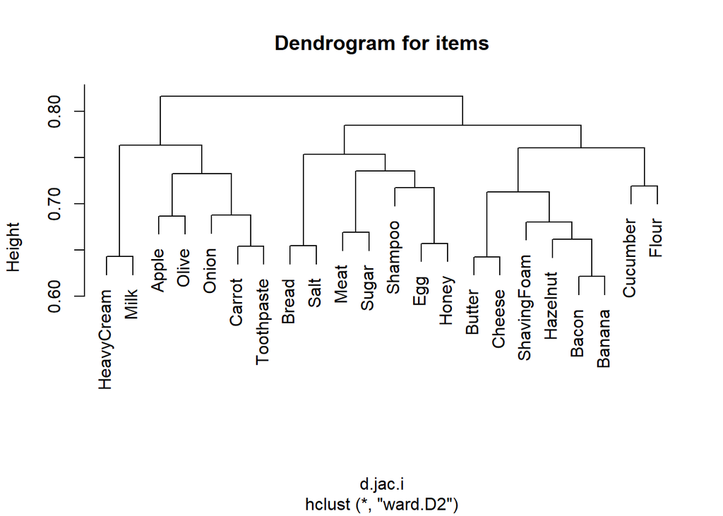

```r
plot(hclust(d.jac.i, method="ward.D2"), main="Dendrogram for items")
```

Some of the branches in the dendrogram align well with expectations, such as butter and cheese or milk and heavy cream, as these items are often associated with similar purchasing patterns. However, some surprising outcomes occurred like pairing of items like carrots and toothpaste, which seems unusual and may indicate an unexpected buying habit or a coincidental pattern in the dataset.

Two additional graphs were created to provide a clearer view of the patterns within the association rules. The first is a grouped matrix plot and the second one is a graph-based visualization that highlights the relationships between items, showcasing how they interact and which items are central to the associations.

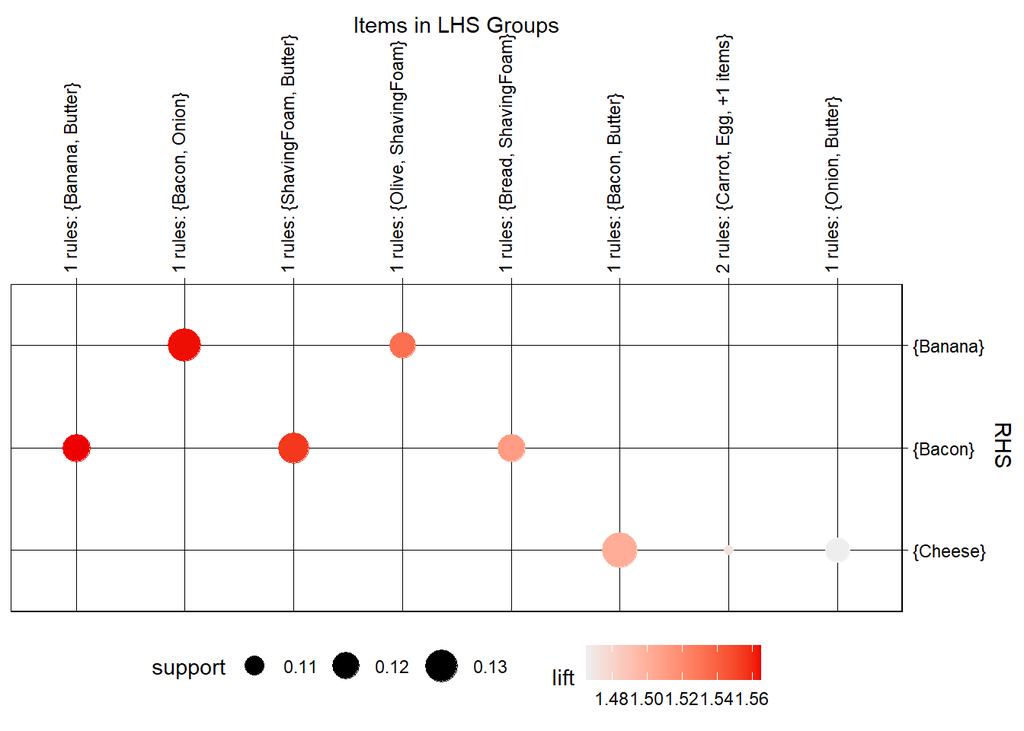

```r
library(arulesViz)
plot(rules, method="grouped")
```

[output not shown]

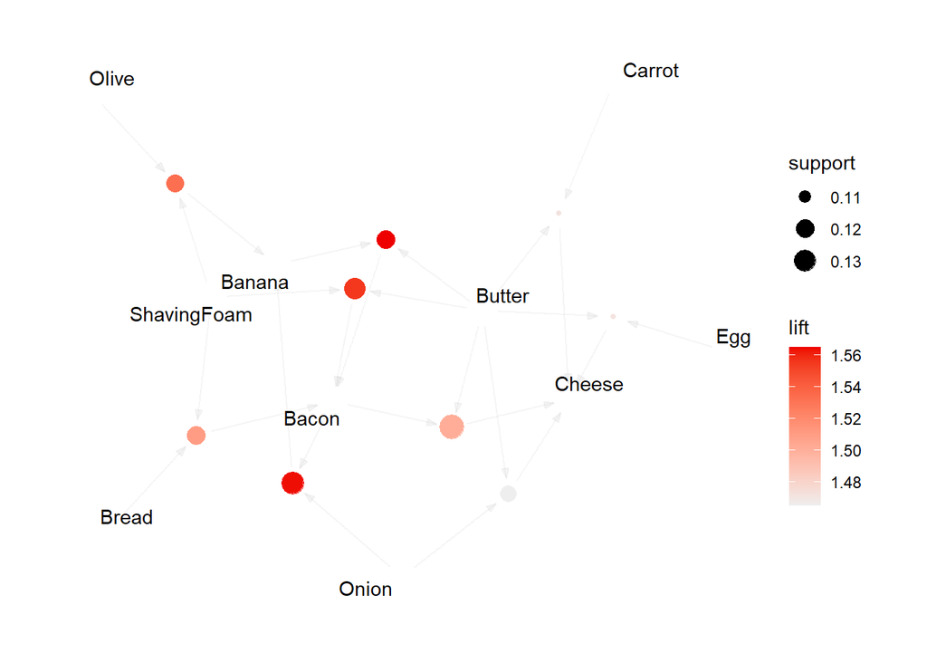

```r
plot(rules, method="graph", control=list(type="items"))
```

## Conclusion

Central items like bacon and butter are key products that often co-occur with others, making them influential in the dataset. Peripheral items like carrot and olive are less connected and may appear in fewer association rules or transactions. These findings highlight the potential for using association rules to inform business decisions, such as optimizing product placement or creating targeted promotions.